# IST 5535 HW8: Linear Model Selection and Regularization

Sayantan Majumdar

2020-03-30

#### 1. What variables are in the final model identified by the simple univariate feature selection?

```r
library(corrplot)
library(mlr)
data <- read.csv('HW8Data.csv')
summary(data)
```

```
##        x1              x2               x3               x4
##  Min.   :2.822   Min.   : 2.241   Min.   : 13.23   Min.   :0.002232
##  1st Qu.:4.553   1st Qu.:19.899   1st Qu.: 57.04   1st Qu.:0.258664
##  Median :5.121   Median :27.248   Median : 81.04   Median :0.482544
##  Mean   :5.086   Mean   :26.899   Mean   : 85.98   Mean   :0.487180
##  3rd Qu.:5.576   3rd Qu.:31.587   3rd Qu.:104.03   3rd Qu.:0.699963
##  Max.   :7.250   Max.   :61.764   Max.   :228.53   Max.   :0.987830
##        x5                x6                y
##  Min.   :-0.5013   Min.   :-1.1483   Min.   : 9.192
##  1st Qu.: 1.2997   1st Qu.:-0.1826   1st Qu.:15.259
##  Median : 2.4111   Median : 0.3070   Median :17.952
##  Mean   : 2.4802   Mean   : 0.2730   Mean   :17.677
##  3rd Qu.: 3.7117   3rd Qu.: 0.7053   3rd Qu.:19.770
##  Max.   : 5.8025   Max.   : 2.2438   Max.   :26.143
```

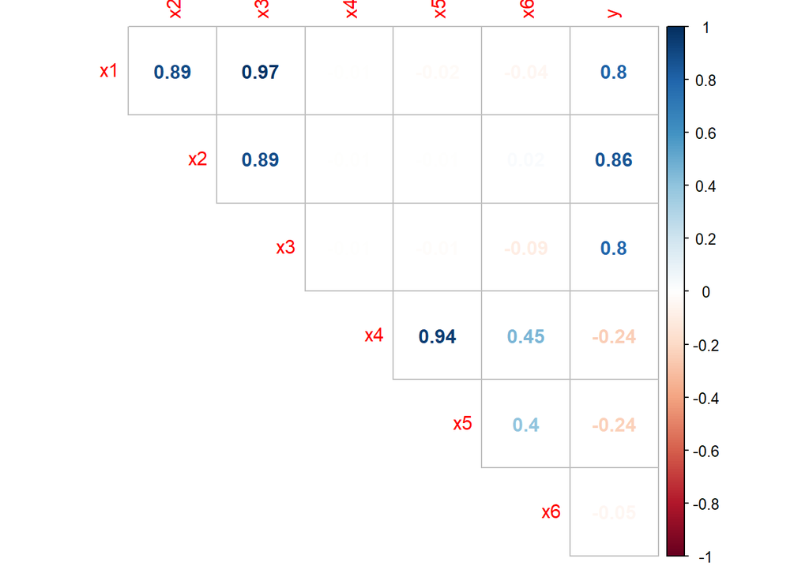

```r
corrplot(cor(data), method = "number", type = "upper", diag = F)
```

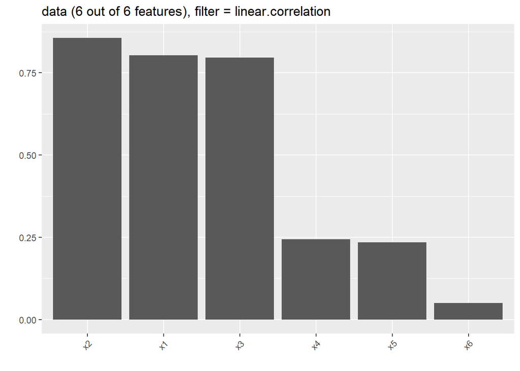

```r
data.task <-  makeRegrTask(data = data, target = "y")
data.fv <- generateFilterValuesData(data.task, method = "linear.correlation")
plotFilterValues(data.fv)
```

```r
data.fit <- lm(y ~ x1 + x2 + x3, data = data)
summary(data.fit)
```

```
##
## Call:
## lm(formula = y ~ x1 + x2 + x3, data = data)
##
## Residuals:
##     Min      1Q  Median      3Q     Max
## -4.9061 -1.1835 -0.0195  1.2041  4.7128
##
## Coefficients:
##             Estimate Std. Error t value Pr(>|t|)
## (Intercept) 7.726896   2.527396   3.057  0.00266 **
## x1          0.704606   0.759385   0.928  0.35501
## x2          0.230501   0.032080   7.185 3.19e-11 ***
## x3          0.001932   0.015351   0.126  0.90003
## ---
## Signif. codes:  0 '***' 0.001 '**' 0.01 '*' 0.05 '.' 0.1 ' ' 1
##
## Residual standard error: 1.815 on 146 degrees of freedom
## Multiple R-squared:  0.7409, Adjusted R-squared:  0.7356
## F-statistic: 139.2 on 3 and 146 DF,  p-value: < 2.2e-16
```

```r
print(BIC(data.fit))
```

```
## [1] 625.5419
```

```r
coefs <- coef(data.fit)
print(coefs)
```

```
## (Intercept)          x1          x2          x3
## 7.726895776 0.704606443 0.230501241 0.001931816
```

```r
var.names <- names(coefs)
```

From the above correlation matrix and feature importance plots, it is clear that x4, x5, and x6 should be removed before constructing the linear model. This is because x1, x2, and x3 have high correlation with the response variable, y. The final model is:

$\hat{y}$ = 7.7268958 + 0.7046064$x_1$ + 0.2305012$x_2$ + 0.0019318$x_3$ + $\epsilon$

#### 2. Use the regsubsets() method in the leaps package to conduct the best subset selection on the whole dataset. Draw a plot to show the dynamics of RSS, Adjusted R$^2$, C$_p$, and BIC across different number of variables.

```r
library(leaps)

train_x <- model.matrix(y ~ ., data = data)[,-1]
train_y <- data$y
nv_max <- 2 ^ (ncol(data) - 1)
fit_best <- regsubsets(x = train_x, y = train_y, nvmax = nv_max)
fit_best_sum <- summary(fit_best)
```

##### Best Subset Summary

RSS = 495.8137247, 392.9388354, 378.1986208, 372.4616468, 371.4491987, 371.3550766 R$^2$ = 0.7311521, 0.7854851, 0.792118, 0.7938594, 0.7929921, 0.7915974 C$_p$ = 44.9260626, 7.3113917, 3.635286, 3.4261138, 5.0362441, 7 BIC = -188.0302305, -217.9015457, -218.6260786, -215.9082591, -211.3059182, -206.3332965

##### Plot to show the dynamics of RSS, Adjusted R2, Cp, and BIC across different number of variables.

```r
plot_model_stats <- function(fit_summary) {
  par(mfrow = c(2, 2))

  plot(fit_summary$rss,
       xlab = "Number of Variables",
       ylab = "RSS",
       type = "l")

  plot(fit_summary$adjr2,
       xlab = "Number of Variables",
       ylab = "Adjusted R2",
       type = "l")
  points(which.max(fit_summary$adjr2),
         fit_summary$adjr2[which.max(fit_summary$adjr2)],
         col = "red", cex = 2, pch = 20)

  plot(fit_summary$cp,
       xlab = " Number of Variables",
       ylab = " Cp",
       type = "l")
  points(which.min(fit_summary$cp),
         fit_summary$cp[which.min(fit_summary$cp)],
         col = "red", cex = 2, pch = 20)

  plot(fit_best_sum$bic,
       xlab = " Number of Variables",
       ylab = " BIC",
       type = "l")
  points(which.min(fit_summary$bic),
         fit_summary$bic[which.min(fit_summary$bic)],
         col = "red", cex = 2, pch = 20)
}
plot_model_stats(fit_best_sum)
```

[output not shown]

If we use BIC as the criterion of model selection, the final model should include 3 predictors.

```r
model_stats <- function(fitted_model, num_var) {
  coefs <- coef(fitted_model, 3)
  print(coefs)
  var.names <- names(coefs)
  data.subset <- data.frame(train_x[, var.names[-1]])
  data.subset$Price <- train_y
  str(data.subset)
}
model_stats(fit_best)
```

```
## (Intercept)          x1          x2          x4
##   8.8864715   0.7891859   0.2304263  -2.9179968
## 'data.frame':    150 obs. of  4 variables:
##  $ x1   : num  4.96 6.77 3.18 5.28 3.66 ...
##  $ x2   : num  30.2 47.2 13.3 31.1 9.9 ...
##  $ x4   : num  0.963 0.297 0.345 0.242 0.343 ...
##  $ Price: num  15.3 22.3 13.3 19.3 12 ...
```

#### 3. Use the regsubsets() method to conduct the forward stepwise selection on the whole dataset. Draw a plot to show the dynamics of RSS, Adjusted R$^2$, C$_p$, and BIC across different number of variables.

```r
fit_fwd <- regsubsets(x = train_x, y = train_y, nvmax = nv_max, method = 'forward')
fit_fwd_sum <- summary(fit_fwd)
plot_model_stats(fit_fwd_sum)
```

[output not shown]

```r
model_stats(fit_fwd)
```

```
## (Intercept)          x1          x2          x4
##   8.8864715   0.7891859   0.2304263  -2.9179968
## 'data.frame':    150 obs. of  4 variables:
##  $ x1   : num  4.96 6.77 3.18 5.28 3.66 ...
##  $ x2   : num  30.2 47.2 13.3 31.1 9.9 ...
##  $ x4   : num  0.963 0.297 0.345 0.242 0.343 ...
##  $ Price: num  15.3 22.3 13.3 19.3 12 ...
```

##### Forward Stepwise Selection Summary

RSS = 495.8137247, 392.9388354, 378.1986208, 372.4616468, 371.4491987, 371.3550766 R$^2$ = 0.7311521, 0.7854851, 0.792118, 0.7938594, 0.7929921, 0.7915974 C$_p$ = 44.9260626, 7.3113917, 3.635286, 3.4261138, 5.0362441, 7 BIC = -188.0302305, -217.9015457, -218.6260786, -215.9082591, -211.3059182, -206.3332965

#### 4. Use the regsubsets() method to conduct the backward stepwise selection on the whole dataset. Draw a plot to show the dynamics of RSS, Adjusted R$^2$, C$_p$, and BIC across different number of variables.

```r
fit_bwd <- regsubsets(x = train_x, y = train_y, nvmax = nv_max, method = 'backward')
fit_bwd_sum <- summary(fit_bwd)
plot_model_stats(fit_bwd_sum)
```

[output not shown]

```r
model_stats(fit_bwd)
```

```
## (Intercept)          x1          x2          x4
##   8.8864715   0.7891859   0.2304263  -2.9179968
## 'data.frame':    150 obs. of  4 variables:
##  $ x1   : num  4.96 6.77 3.18 5.28 3.66 ...
##  $ x2   : num  30.2 47.2 13.3 31.1 9.9 ...
##  $ x4   : num  0.963 0.297 0.345 0.242 0.343 ...
##  $ Price: num  15.3 22.3 13.3 19.3 12 ...
```

##### Backward Stepwise Selection Summary

RSS = 495.8137247, 392.9388354, 378.1986208, 372.4616468, 371.4491987, 371.3550766 R$^2$ = 0.7311521, 0.7854851, 0.792118, 0.7938594, 0.7929921, 0.7915974 C$_p$ = 44.9260626, 7.3113917, 3.635286, 3.4261138, 5.0362441, 7 BIC = -188.0302305, -217.9015457, -218.6260786, -215.9082591, -211.3059182, -206.3332965

Therefore, the best subset selection, forward stepwise selection, and backward stepwise subset selection methods all result in the same model that includes x1, x2, and x4 as predictor variables.

#### 5. Fit a lasso model to fit the whole dataset. Use 10-fold cross-validation to select the optimal value of $\lambda$. Create plots of the cross-validation error as a function of $\lambda$. Use the optimal value of $\lambda$ to build the final lasso model.

```r
library(glmnet)
grid <- 10^seq(10, -2, length = 100)
print(grid)
```

```
##   [1] 1.000000e+10 7.564633e+09 5.722368e+09 4.328761e+09 3.274549e+09
##   [6] 2.477076e+09 1.873817e+09 1.417474e+09 1.072267e+09 8.111308e+08
##  [11] 6.135907e+08 4.641589e+08 3.511192e+08 2.656088e+08 2.009233e+08
##  [16] 1.519911e+08 1.149757e+08 8.697490e+07 6.579332e+07 4.977024e+07
##  [21] 3.764936e+07 2.848036e+07 2.154435e+07 1.629751e+07 1.232847e+07
##  [26] 9.326033e+06 7.054802e+06 5.336699e+06 4.037017e+06 3.053856e+06
##  [31] 2.310130e+06 1.747528e+06 1.321941e+06 1.000000e+06 7.564633e+05
##  [36] 5.722368e+05 4.328761e+05 3.274549e+05 2.477076e+05 1.873817e+05
##  [41] 1.417474e+05 1.072267e+05 8.111308e+04 6.135907e+04 4.641589e+04
##  [46] 3.511192e+04 2.656088e+04 2.009233e+04 1.519911e+04 1.149757e+04
##  [51] 8.697490e+03 6.579332e+03 4.977024e+03 3.764936e+03 2.848036e+03
##  [56] 2.154435e+03 1.629751e+03 1.232847e+03 9.326033e+02 7.054802e+02
##  [61] 5.336699e+02 4.037017e+02 3.053856e+02 2.310130e+02 1.747528e+02
##  [66] 1.321941e+02 1.000000e+02 7.564633e+01 5.722368e+01 4.328761e+01
##  [71] 3.274549e+01 2.477076e+01 1.873817e+01 1.417474e+01 1.072267e+01
##  [76] 8.111308e+00 6.135907e+00 4.641589e+00 3.511192e+00 2.656088e+00
##  [81] 2.009233e+00 1.519911e+00 1.149757e+00 8.697490e-01 6.579332e-01
##  [86] 4.977024e-01 3.764936e-01 2.848036e-01 2.154435e-01 1.629751e-01
##  [91] 1.232847e-01 9.326033e-02 7.054802e-02 5.336699e-02 4.037017e-02
##  [96] 3.053856e-02 2.310130e-02 1.747528e-02 1.321941e-02 1.000000e-02
```

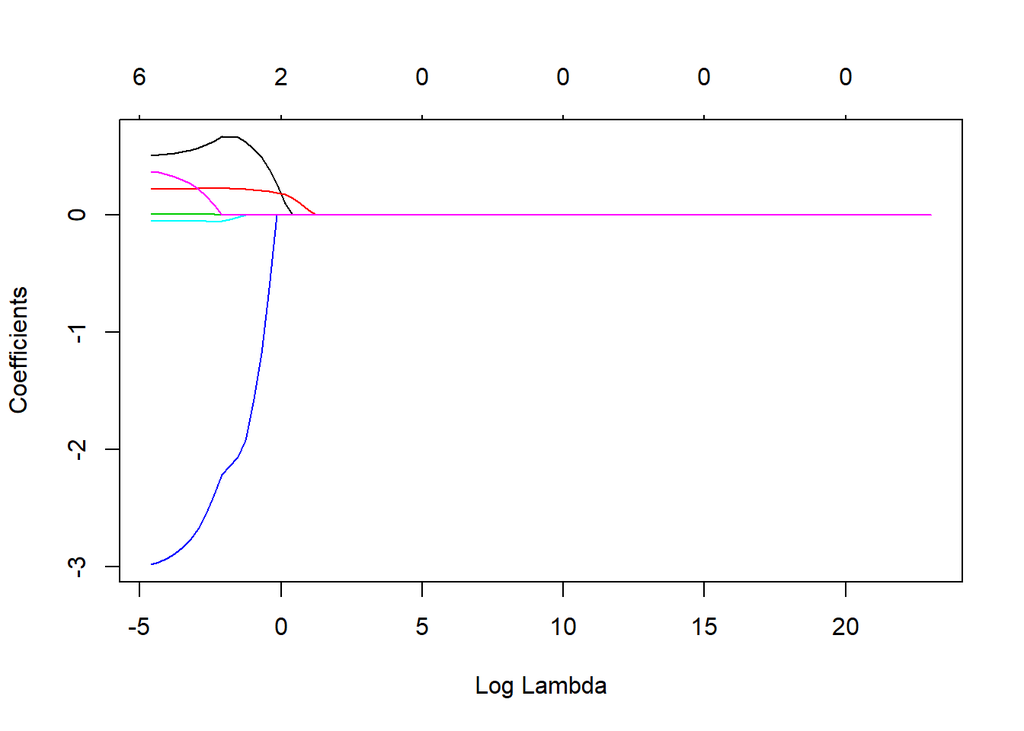

```r
lasso_full <- glmnet(x = train_x, y = train_y, alpha = 1, lambda = grid)
plot(lasso_full, xvar = 'lambda')
```

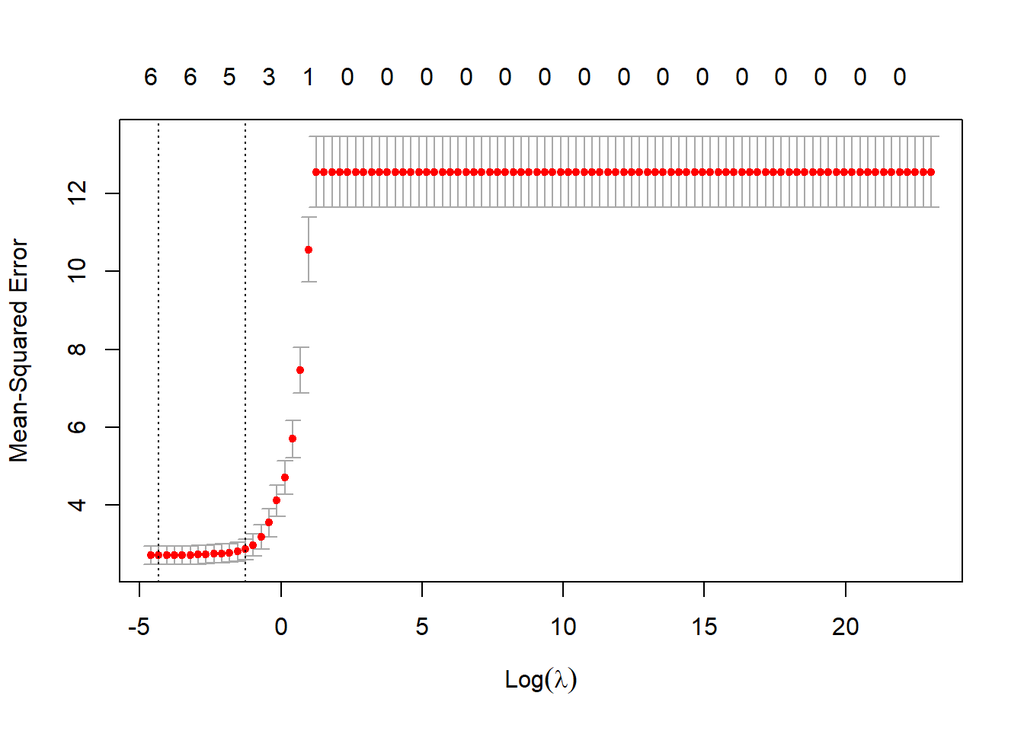

```r
#k-folds CV
set.seed(1)
cv_out <- cv.glmnet(train_x, train_y, alpha = 1, lambda = grid, nfolds = 10)
plot(cv_out)
```

```r
best_lambda <- cv_out$lambda.min
print(best_lambda)
```

```
## [1] 0.01321941
```

```r
coefs <- predict(lasso_full, type = "coefficients", s = best_lambda)
print(coefs)
```

```
## 7 x 1 sparse Matrix of class "dgCMatrix"
##                        1
## (Intercept)  9.936760501
## x1           0.510649654
## x2           0.220940724
## x3           0.007847722
## x4          -2.960772184
## x5          -0.052662868
## x6           0.359164333
```

$\hat{y}$ = 9.9367605 + 0.5106497$x_1$ + 0.2209407$x_2$ + 0.0078477$x_3$ + -2.9607722$x_4$ + -0.0526629$x_5$ + 0.3591643$x_6$ + $\epsilon$

So the final model doesn’t do any variable selection.